# 01 — Panorama : les discours de François en voyage

**Corpus.** Les discours (rubrique *Speeches* de vatican.va) **en anglais** prononcés **sur place** pendant les voyages apostoliques **hors d'Italie** (2013-2024). Les discours du Vatican, de Rome et des visites en Italie sont exclus, ainsi que le voyage à Dubaï (COP28, 2023), annulé. Les homélies ne sont pas incluses.

**Méthode de sélection** (`acquisition/telecharger_discours.py` puis `acquisition/preparer_corpus.py`). Les dates de chaque voyage sont lues dans son titre sur vatican.va ; on garde les discours de ces dates dont l'en-tête mentionne le voyage (« Apostolic Journey », « Pilgrimage »…). Les conférences de presse et échanges avec les journalistes, surtout dans l'avion, sont écartés : ils ne sont pas prononcés dans le pays et contiennent les questions des journalistes.

Ce notebook décrit le corpus : volumes par voyage, pays, continent et public, longueur, qualité, puis la recherche d'un mot.

```python
import sys, re
from pathlib import Path
ROOT = next(p for p in [Path.cwd(), *Path.cwd().parents] if (p / "outils" / "analyse_corpus.py").exists())
sys.path.insert(0, str(ROOT / "outils"))
import numpy as np
import pandas as pd
import matplotlib.pyplot as plt
from IPython.display import display, HTML
import analyse_corpus as ac

cmap = ac.style()
ac.RESULTATS.mkdir(exist_ok=True)
pd.set_option("display.max_colwidth", 110)
MOIS = ["janv.", "févr.", "mars", "avr.", "mai", "juin", "juil.", "août", "sept.", "oct.", "nov.", "déc."]

df = ac.charger()
ac.tuiles([
    ("Discours", ac.nombre(len(df))),
    ("Voyages", df["voyage"].nunique()),
    ("Pays visités", df.loc[~df["iso"].isin(["", "EN_VOL"]), "iso"].nunique()),
    ("Mots", f"{df['n_mots'].sum() / 1e3:,.0f} k".replace(",", " ")),
    ("Période", f"{df['date'].min():%m/%Y} → {df['date'].max():%m/%Y}"),
])
```

Discours

342

Voyages

47

Pays visités

66

Mots

543 k

Période

07/2013 → 12/2024

## Les voyages

Un trait par voyage ; sa longueur est le nombre de discours, sa couleur le continent principal du voyage. L'absence de voyage en 2020 correspond à la pandémie.

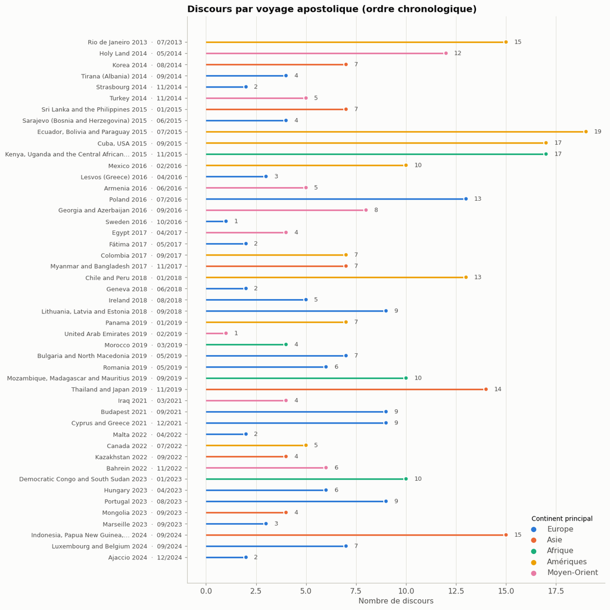

```python
voyages = (df.groupby("voyage")
             .agg(debut=("date", "min"), discours=("event_id", "size"), mots=("n_mots", "sum"),
                  pays=("pays", lambda s: ", ".join(sorted(set(s) - {"En vol", "Inconnu"}))),
                  continent=("continent", lambda s: s.mode().iat[0] if s.notna().any() else np.nan))
             .sort_values("debut"))
fig, ax = plt.subplots(figsize=(12, 12))
y = np.arange(len(voyages))
couleurs = [ac.COULEUR_CONTINENT.get(c, ac.GRIS) for c in voyages["continent"]]
ax.hlines(y, 0, voyages["discours"], color=couleurs, linewidth=2.2)
ax.scatter(voyages["discours"], y, color=couleurs, s=40, zorder=3, edgecolors=ac.SURFACE, linewidths=1.5)
for i, (n, d) in enumerate(zip(voyages["discours"], voyages["debut"])):
    ax.text(n + .4, i, f"{n}", va="center", fontsize=8.5, color=ac.ENCRE_2)
ax.set_yticks(y, [f"{v}  ·  {d:%m/%Y}" for v, d in zip(voyages.index, voyages["debut"])], fontsize=8.5)
ax.invert_yaxis(); ax.grid(axis="y", visible=False)
for c in ac.ORDRE_CONTINENTS:
    if (voyages["continent"] == c).any():
        ax.scatter([], [], color=ac.COULEUR_CONTINENT[c], label=c, s=40)
ax.legend(loc="lower right", title="Continent principal", title_fontsize=9)
ax.set(xlabel="Nombre de discours", title="Discours par voyage apostolique (ordre chronologique)")
fig.tight_layout()
fig.savefig(ac.RESULTATS / "01_discours_par_voyage.png", dpi=160, bbox_inches="tight")
plt.show()
```

## Par année et par continent

Le nombre de discours dépend du nombre de voyages et de leur durée. L'histogramme empile les continents du lieu du discours.

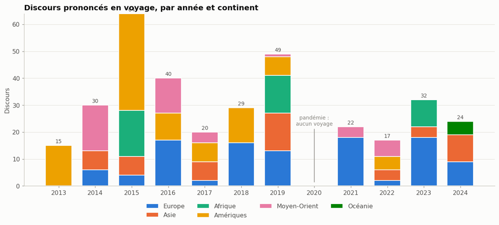

```python
an = (df.assign(c=df["continent"].astype(str).replace("nan", "En vol / inconnu"))
        .pivot_table(index="annee", columns="c", values="event_id", aggfunc="size").fillna(0)
        .reindex(range(2013, 2025), fill_value=0))
fig, ax = plt.subplots(figsize=(12, 5.5))
bas = np.zeros(len(an))
for c in ac.ORDRE_CONTINENTS + ["En vol / inconnu"]:
    if c in an and an[c].sum():
        ax.bar(an.index, an[c], bottom=bas, width=.72, label=c, edgecolor=ac.SURFACE, linewidth=1.2,
               color=ac.COULEUR_CONTINENT.get(c, ac.GRIS))
        bas += an[c].to_numpy()
for x, v in zip(an.index, bas):
    if v:
        ax.text(x, v + .5, f"{int(v)}", ha="center", va="bottom", fontsize=9, color=ac.ENCRE_2)
ax.annotate("pandémie :\naucun voyage", (2020, 1), xytext=(2020, bas.max() * .35), ha="center",
            fontsize=9, color=ac.MUET, arrowprops=dict(arrowstyle="-", color=ac.MUET))
ax.set_xticks(an.index); ax.grid(axis="x", visible=False)
ax.set(ylabel="Discours", title="Discours prononcés en voyage, par année et continent")
ax.legend(ncol=4, loc="upper center", bbox_to_anchor=(.5, -.07))
fig.tight_layout()
fig.savefig(ac.RESULTATS / "01_discours_par_annee.png", dpi=160, bbox_inches="tight")
plt.show()
```

## À qui parle-t-il ?

Le **type de public** est déduit du titre du discours (« Meeting with Authorities… », « Meeting with Young People… »). Les règles sont dans `outils/analyse_corpus.py` (`PUBLICS`) ; le tableau final montre des titres de chaque catégorie pour vérifier le classement, notamment « Autres rencontres ».

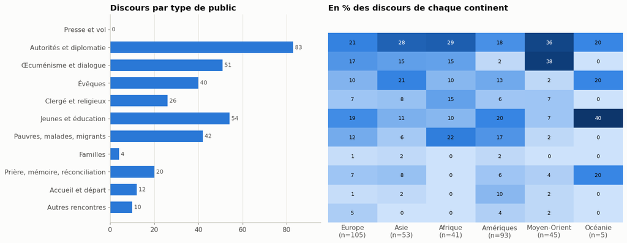

| public | exemples de titres |
| --- | --- |
| Autorités et diplomatie | Apostolic Journey to Armenia: Meeting with Civil Authorities and the Diplomatic Corps at the Presidential ... |
| Œcuménisme et dialogue | Apostolic Journey to Latvia: Ecumenical prayer in the Rigas Doms (24 September 2018) \| Apostolic Journey -... |
| Évêques | Apostolic Journey to Thailand: Meeting with the Bishops of Thailand and FABC at the Blessed Nicholas Boonk... |
| Clergé et religieux | Celebration of Vespers with priests, men and women religious, seminarians and various lay movements in the... |
| Jeunes et éducation | Apostolic Journey to Luxembourg and Belgium: Meeting with University Students in the Aula Magna of the Uni... |
| Pauvres, malades, migrants | Apostolic Journey to Slovakia: Private Visit to the “Bethlehem Center” (13 September 2021) \| Apostolic Jou... |
| Familles | Apostolic Journey to Mexico: Meeting with families in the “Víctor Manuel Reyna” stadium (Tuxtla Gutiérrez,... |
| Prière, mémoire, réconciliation | Apostolic Journey to Papua New Guinea: Meeting with the Faithful of the Diocese of Vanimo at the Esplanade... |
| Accueil et départ | Apostolic Journey - Cuba: Welcoming ceremony at “José Martí” International Airport (Havana, 19 September 2... |
| Autres rencontres | Apostolic Journey - United States of America: Greeting to the organizing committee, volunteers and benefac... |

```python
pub = df["public"].value_counts().reindex(ac.ORDRE_PUBLICS).dropna()
fig, axes = plt.subplots(1, 2, figsize=(14, 5.5), gridspec_kw={"width_ratios": [1, 1.4]})
axes[0].barh(pub.index, pub.values, color=ac.SERIES[0], height=.65)
for i, v in enumerate(pub.values):
    axes[0].text(v, i, f" {int(v)}", va="center", fontsize=9, color=ac.ENCRE_2)
axes[0].invert_yaxis(); axes[0].grid(axis="y", visible=False)
axes[0].set(title="Discours par type de public", xlim=(0, pub.max() * 1.15))
# Les discours en vol n'ont pas de continent : la ligne « Presse et vol » est omise à droite.
part = pd.crosstab(df["public"], df["continent"], normalize="columns").reindex(pub.index).fillna(0)
part.loc["Presse et vol"] = np.nan
n_cont = df["continent"].value_counts()
part.columns = [f"{c}\n(n={n_cont[c]})" for c in part.columns]
ac.carte_chaleur(axes[1], part * 100, cmap, fmt="{:.0f}")
axes[1].set_yticks([]); axes[1].set_title("En % des discours de chaque continent")
fig.tight_layout()
fig.savefig(ac.RESULTATS / "01_publics.png", dpi=160, bbox_inches="tight")
plt.show()
exemples = df.groupby("public", observed=True)["titre"].apply(lambda s: " | ".join(s.sample(min(3, len(s)), random_state=0)))
display(exemples.to_frame("exemples de titres"))
```

## Longueur des discours

Chaque point est un discours ; la boîte couvre la moitié centrale, le trait épais est la médiane.

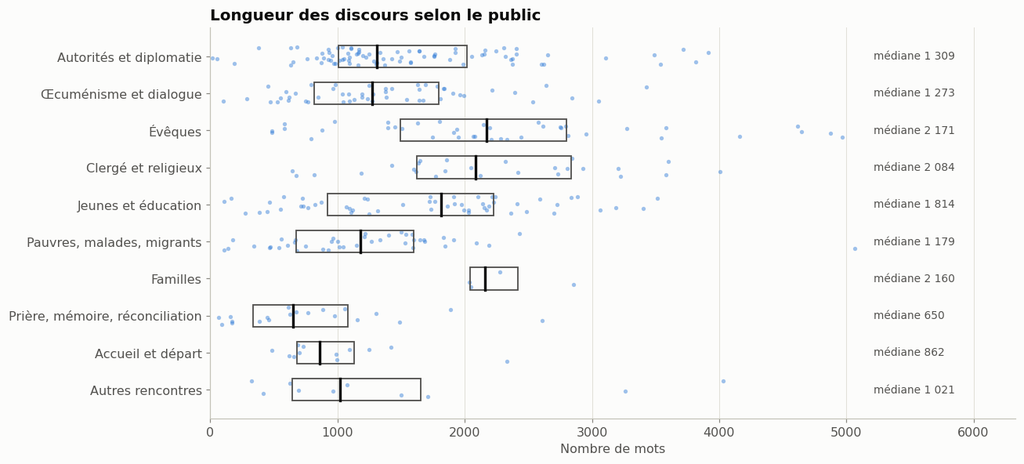

|  | date | pays | titre | n_mots |
| --- | --- | --- | --- | --- |
| 65 | 2015-07-09 | Bolivie | Apostolic Journey - Bolivia: Participation at the Second World Meeting of Popular Movements at the Expo Fe... | 5065 |
| 130 | 2016-07-27 | Pologne | Apostolic Journey to Poland: Meeting with the Polish Bishops in the Cathedral of Kraków (27 July 2016) | 4965 |
| 200 | 2019-01-24 | Panama | Apostolic Journey to Panama: Meeting with central american Bishops (Church of San Francisco de Asis, 24 Ja... | 4878 |
| 111 | 2016-02-13 | Mexique | Apostolic Journey to Mexico: Meeting with the Bishops of Mexico gathered in the Cathedral (Mexico City, 13... | 4649 |
| 10 | 2013-07-27 | Brésil | Meeting with the Bishops of Brazil in the Archbishop's House of Rio de Janeiro (27 July 2013) | 4618 |
| 158 | 2017-09-07 | Colombie | Apostolic Journey to Colombia: Encounter with the Bishops (Reception Room of the Cardinal's Palace, Bogotá... | 4164 |

```python
publics = [p for p in ac.ORDRE_PUBLICS if (df["public"] == p).any()]
fig, ax = plt.subplots(figsize=(12, 5.5))
rng = np.random.default_rng(0)
for i, p in enumerate(publics):
    v = df.loc[df["public"].eq(p), "n_mots"]
    ax.scatter(v, i + rng.uniform(-.25, .25, len(v)), s=12, color=ac.SERIES[0], alpha=.45, linewidths=0)
    q1, med, q3 = v.quantile([.25, .5, .75])
    ax.add_patch(plt.Rectangle((q1, i - .3), q3 - q1, .6, fill=False, edgecolor=ac.ENCRE_2, linewidth=1.2))
    ax.plot([med, med], [i - .3, i + .3], color=ac.ENCRE, linewidth=2.2)
    ax.text(df["n_mots"].max() * 1.03, i, f"médiane {med:,.0f}".replace(",", " "), va="center", fontsize=9, color=ac.ENCRE_2)
ax.set_yticks(range(len(publics)), publics); ax.invert_yaxis()
ax.grid(axis="y", visible=False)
ax.set(xlabel="Nombre de mots", title="Longueur des discours selon le public", xlim=(0, df["n_mots"].max() * 1.25))
fig.tight_layout(); plt.show()
display(df.nlargest(6, "n_mots")[["date", "pays", "titre", "n_mots"]])
```

## Contrôle qualité

À examiner avant d'interpréter : pays non attribué, lieu absent de l'en-tête, en-tête non détecté (il peut rester dans le corps), textes très courts. Les textes écartés à la préparation (conférences de presse, discours prononcés au Vatican) sont décrits dans `acquisition/preparer_corpus.py`.

```python
qualite = pd.Series({
    "discours": len(df),
    "pays non attribué": df["iso"].eq("").sum(),
    "conférences de presse en vol": df["en_vol"].sum(),
    "lieu absent de l'en-tête": df["venue_raw"].eq("").sum(),
    "en-tête non détecté": df["cleaning_status"].eq("unsegmented").sum(),
    "moins de 150 mots": df["n_mots"].lt(150).sum(),
    "textes identiques": df["text"].duplicated().sum(),
}, name="nombre")
display(qualite.to_frame())
display(df.loc[df["iso"].eq(""), ["date", "voyage", "titre", "venue_raw"]])
qualite.to_csv(ac.RESULTATS / "qualite_corpus.csv", encoding="utf-8-sig")
```

|  | nombre |
| --- | --- |
| discours | 342 |
| pays non attribué | 0 |
| conférences de presse en vol | 0 |
| lieu absent de l'en-tête | 17 |
| en-tête non détecté | 0 |
| moins de 150 mots | 8 |
| textes identiques | 0 |

|  | date | voyage | titre | venue_raw |
| --- | --- | --- | --- | --- |

## Suivre un mot

Modifier `REQUETE` (expression régulière en anglais, insensible à la casse). À gauche, le taux pour 10 000 mots par voyage, dans l'ordre chronologique ; à droite, la part des discours qui l'emploient selon le public. Les extraits permettent de vérifier le sens des occurrences.

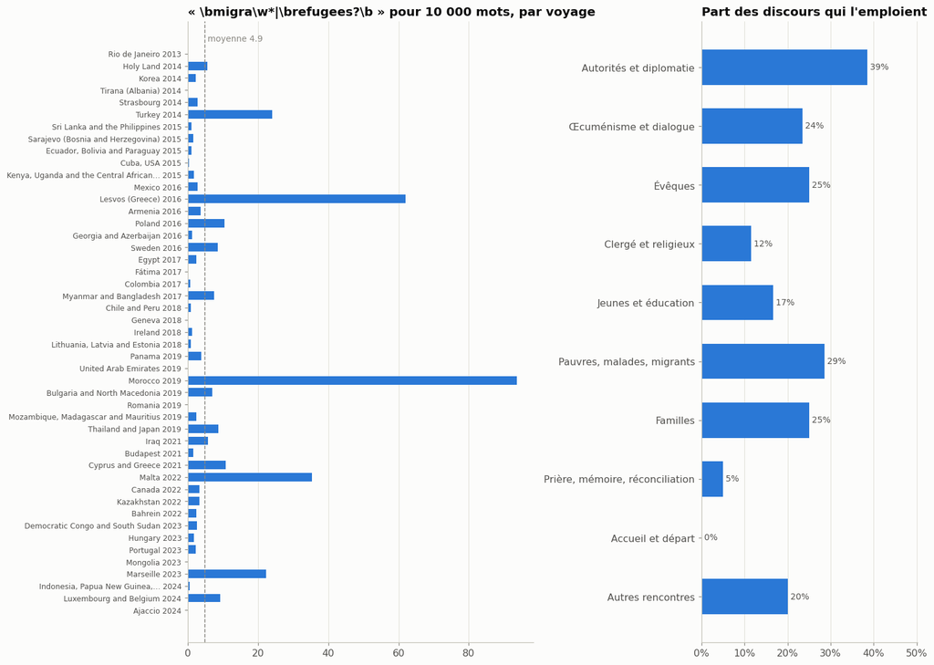

| 07/07/2015 | Équateur | …. Ecuador, like many Latin American nations, is now experiencing profound social and cultural changes, new challenges which need to be faced by every sector of society. **Migration**, overcrowded cit… |
| --- | --- | --- |
| 31/01/2023 | RD Congo | …variegated, its history has not been comparably blessed. Torn by war, the Democratic Republic of the Congo continues to witness within its confines conflicts and forced **migrations**, and to suffer … |
| 09/09/2019 | Maurice | …rn of the ability to acknowledge, respect and harmonize existing differences in view of a common project. This sums up the history of your people, born of the arrival of **migrants** from different h… |
| 05/03/2021 | Irak | …persecution, the fragility of basic infrastructures and the ongoing struggle for economic and personal security that has frequently led to internal displacements and the **migration** of many people,… |
| 30/03/2019 | Maroc | … to devise adequate solutions for reversing the trend of global warming and to achieve the goal of eliminating poverty (cf. Laudato Si’ , 175). Similarly, today’s grave **migration** crisis represent… |
| 27/07/2022 | Canada | …ment, on the needs and rights of individuals, while frequently neglecting their duties with regard to the most weak and vulnerable of our brothers and sisters: the poor, **migrants**, the elderly, th… |
| 03/12/2021 | Chypre | …ith affection and gratitude the representatives of the different Christian confessions present in Cyprus. I want to say, from my heart, a big “thanks” to you, the young **migrants** who offered your … |
| 27/09/2024 | Belgique | … this regard, I would like to express sincere words of gratitude: Thank you! Thank you, for through expanding boundaries, you have become a welcoming environment for the **refugees** obliged to flee … |
| 23/09/2023 | France | … all, and it is turning the Mediterranean, the mare nostrum , from the cradle of civilization into the mare mortuum , the graveyard of dignity : it is the stifled cry of **migrant** brothers and sist… |
| 07/05/2019 | Macédoine du Nord | …tribution of various international Agencies, the Red Cross, Caritas and several non-governmental organizations – to welcome and provide assistance to the great number of **migrants** and refugees com… |

```python
REQUETE = r"\bmigra\w*|\brefugees?\b"
rx = re.compile(REQUETE, re.I)
d = df.assign(occ=df["text"].map(lambda t: len(rx.findall(t))))
par_voyage = d.groupby("voyage").agg(occ=("occ", "sum"), mots=("n_mots", "sum"), debut=("date", "min")).sort_values("debut")
taux = par_voyage["occ"] / par_voyage["mots"] * 1e4
moyenne = d["occ"].sum() / d["n_mots"].sum() * 1e4

fig, axes = plt.subplots(1, 2, figsize=(14, 10), gridspec_kw={"width_ratios": [1.6, 1]})
axes[0].barh(taux.index, taux.values, color=ac.SERIES[0], height=.7)
axes[0].axvline(moyenne, color=ac.MUET, linestyle="--", linewidth=1)
axes[0].text(moyenne, -1, f" moyenne {moyenne:.1f}", color=ac.MUET, fontsize=9)
axes[0].invert_yaxis(); axes[0].grid(axis="y", visible=False); axes[0].tick_params(axis="y", labelsize=8)
axes[0].set(title=f"« {REQUETE} » pour 10 000 mots, par voyage")
part = d.groupby("public", observed=True)["occ"].apply(lambda s: s.gt(0).mean()).reindex(publics)
axes[1].barh(part.index, part.values, color=ac.SERIES[0], height=.6)
for i, v in enumerate(part.values):
    axes[1].text(v, i, f" {v:.0%}", va="center", fontsize=9, color=ac.ENCRE_2)
axes[1].invert_yaxis(); axes[1].grid(axis="y", visible=False)
axes[1].xaxis.set_major_formatter(lambda v, _: f"{v:.0%}")
axes[1].set(title="Part des discours qui l'emploient", xlim=(0, max(.05, part.max() * 1.3)))
fig.tight_layout(); plt.show()

lignes = []
for r in d.loc[d["occ"].gt(0)].sample(min(10, d["occ"].gt(0).sum()), random_state=1).itertuples():
    m = rx.search(r.text)
    a, b = max(0, m.start() - 170), m.end() + 170
    lignes.append(f"<tr><td style='white-space:nowrap'>{r.date:%d/%m/%Y}</td><td>{r.pays}</td>"
                  f"<td>…{r.text[a:m.start()]}<b style='background:#cde2fb'>{m.group()}</b>{r.text[m.end():b]}… "
                  f"<a href='{r.source_url}' target='_blank'>source</a></td></tr>")
display(HTML("<table style='font-size:12.5px'>" + "".join(lignes) + "</table>"))
```

## Lire un discours

Choisir un discours par mot du titre ; on compare l'en-tête retiré et le début du corps.

```python
TITRE_CONTIENT = "United Nations"
choix = df.loc[df["titre"].str.contains(TITRE_CONTIENT, case=False, regex=False)]
if choix.empty:
    print("Aucun titre ne correspond.")
else:
    r = choix.iloc[0]
    print(r["titre"], "|", r["pays"], "|", r["public"], "\n", r["source_url"])
    print("\nEN-TÊTE :\n", r["header"][:700])
    print("\nCORPS (début) :\n", r["text"][:1800])
df.drop(columns=["text", "header"]).to_csv(ac.RESULTATS / "inventaire_analyse.csv", index=False, encoding="utf-8-sig")
```

```
Apostolic Journey - United Nations: Greeting to the personnel of the United Nations (25 September 2015) | États-Unis | Autorités et diplomatie
 https://www.vatican.va/content/francesco/en/speeches/2015/september/documents/papa-francesco_20150925_onu-saluto.html

EN-TÊTE :
 APOSTOLIC JOURNEY OF HIS HOLINESS POPE FRANCIS TO CUBA, TO THE UNITED STATES OF AMERICA AND VISIT TO THE UNITED NATIONS HEADQUARTERS (19-28 SEPTEMBER 2015)
MEETING WITH THE PERSONNEL OF THE UNITED NATIONS
GREETING OF THE HOLY FATHER
United Nations Headquarters, New York Friday, 25 September 2015
[ Multimedia ]

CORPS (début) :
 Dear Friends,

On the occasion of my visit to the United Nations, I am pleased to greet you, the men and women who are, in many ways, the backbone of this Organization. I thank you for your welcome, and I am grateful for all that you have done to prepare for my visit. I would ask you also to offer my greetings to …

The vast majority of the work done here is not of the kind that makes the news. Behind the scenes, your daily efforts make possible many of the diplomatic, cultural, economic and political initiatives of the United Nations, which are so important for meeting the hopes and expectations of the peoples…

Your quiet and devoted work not only contributes to the betterment of the United Nations. It also has great significance for you personally. For how we work expresses our dignity and the kind of persons we are.

Many of you have come to this city from countries the world over. As such, you are a microcosm of the peoples which this Organization represents and seeks to serve. Like so many other people worldwide, you are concerned about your children’s welfare and education. You worry about the future of the p…
```